# Bank Marketing Campaign Analysis

## Investigation Overview

In this investigation, I wanted to understand what factors affected the results of the bank's marketing campaign, and by understanding the dataset and getting results; we can use them to optimize the performance of future campaigns.

## Data Overview

The data includes about 11000 observations of the marketing campaign made by the bank to ask clients to subscribe to term deposits. Data about clients include their age, balance, how often they were contacted, duration of contacts and their marital status. It also includes wheter they have housing or personal loans or they have defaults in their credit.

## Effect of job on the outcome

### The analysis of the data showed that Retired and Students were significantly more likely to subscribe to term deposits while jobs like Blue-collar and Services were less likely to subscribe.

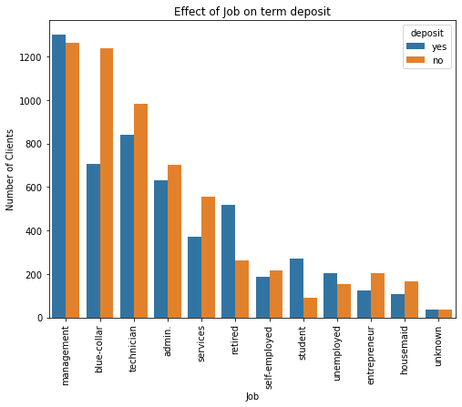

## Effect of marital status on the outcome

### It was found that Married people are less likely to subscribe

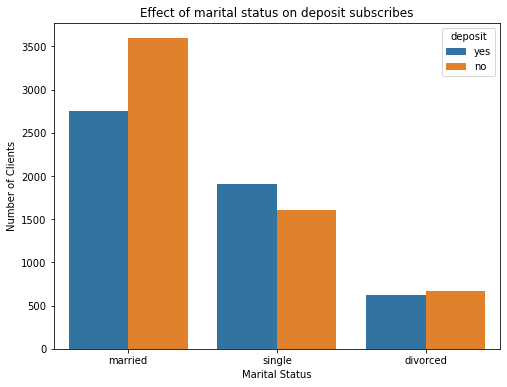

## Effect of Housing Loans

### It was found that people who have housing loans are less likely to subscribe

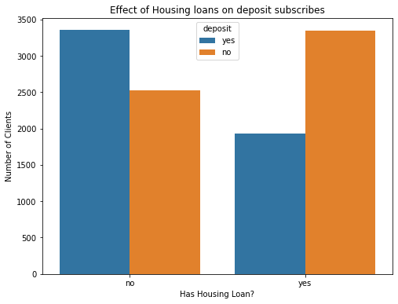

## Effect of Device used

### People who use cellular subscribe more often than other devices

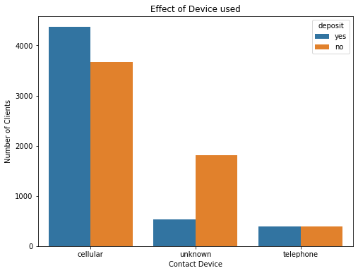

## Effect of Age on the outcome

### It was found that people who are younger than 35 or older than 60 are more likely to subscribe

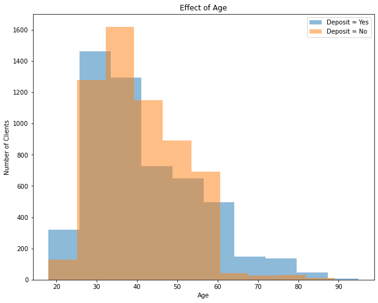

## Effect of Balance on the outcome

### It was found that people with higher balance in their account are more likely to subscribe

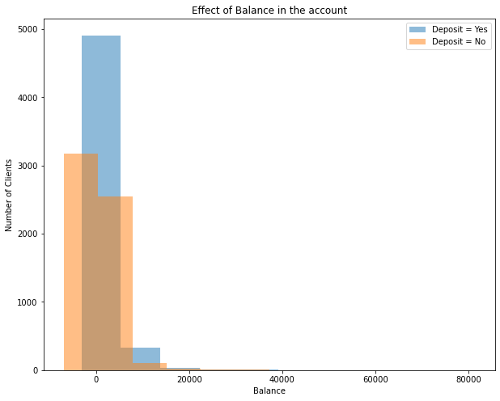

## Effect of Duration on the outcome

### It was found that the more duration a client takes the more likely he/she is to subscribe

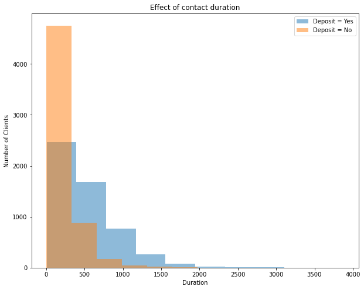

## It was noticed that when people are contacted fewer number of times, and their contact duration is high. They are more likely to subscribe

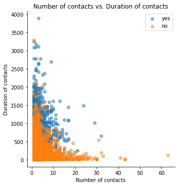